# 第2回 ベイズ勉強会：多変量の推定

Taka-aki Asano

2017/4/21

最初に、必要なパッケージを読み込んでおく。

```r
library("geoR") ## スケールされた逆カイ二乗分布を使うのに必要
library("ggplot2")
library("plyr")
```

# 無情報事前分布を使った正規分布の推定

## スケールされた逆カイ二乗分布

Chap.3で出てきた、スケールされた逆カイ二乗分布がどのような分布かをここで確認しておこう。逆カイ二乗分布は、正規分布の尺度パラメタを推定するときに、共役事前分布として用いる。

逆カイ二乗分布のパラメタは、自由度$\nu$と尺度母数$s$の2つである。
$$x \sim \mathrm{Inv}-\chi^2 (\nu, s^2)$$
なお、確率密度関数は、
$$p(\theta|\nu, s^2) = \frac{(\nu/2)^{\nu/2}}{\Gamma(\nu/2)} s^\nu \theta^{-(\nu/2+1)} \exp\left( -\frac{\nu s^2}{2\theta}\right)$$
で表される。

尺度母数$s$を固定して、自由度$\nu$を動かして分布の変化を確認しよう。

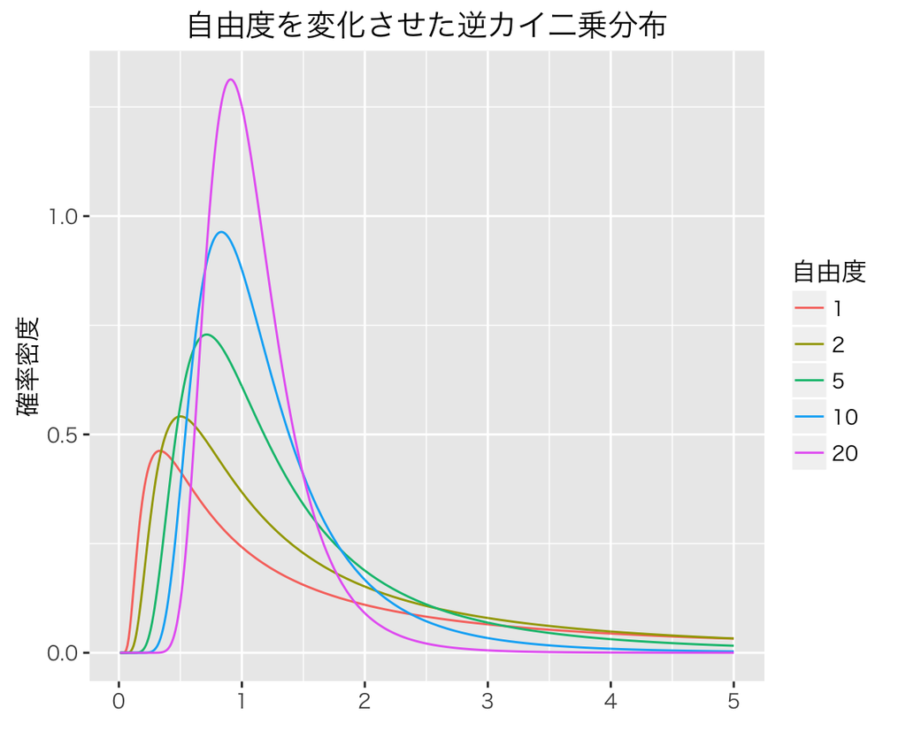

```r
nu_vec <- c(1, 2, 5, 10, 20) ## 自由度ベクトル
s <- 1 ## 尺度母数

# 確率密度の計算
theta <- seq(0.01, 5.0, by = 0.01)
invchi_pdf <- data.frame(theta = rep(theta, 5), pdf = rep(NA, 5*500),
                         nu = c(rep(1, 500), rep(2, 500), rep(5, 500),
                                rep(10, 500), rep(20, 500)))
for (i in 1:5) {
  invchi_pdf$pdf[invchi_pdf$nu == nu_vec[i]] <- dinvchisq(theta, nu_vec[i], s)
}

# 図示
pdf1 <- ggplot(invchi_pdf,
               aes(theta, pdf,
                   group = factor(nu, levels = c("1", "2", "5", "10", "20")),
                   color = factor(nu, levels = c("1", "2", "5", "10", "20")))) +
  geom_line() +
  labs(x = "", y = "確率密度", title = "自由度を変化させた逆カイ二乗分布",
       color = "自由度")
print(pdf1)
```

逆に自由度$\nu$を固定して、尺度母数$s$を動かして分布の変化を確認しよう。

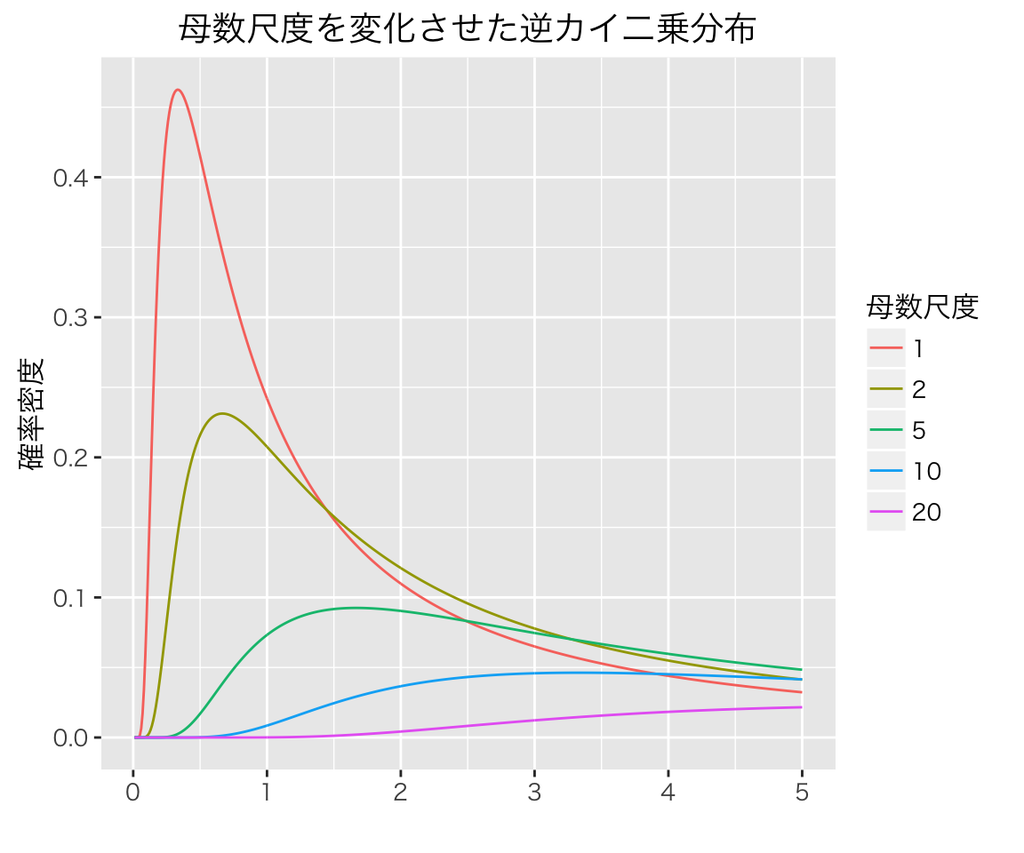

```r
nu <- 1 ## 自由度
s_vec <- c(1, 2, 5, 10, 20) ## 尺度母数ベクトル

# 確率密度の計算
theta <- seq(0.01, 5.0, by = 0.01)
invchi_pdf <- data.frame(theta = rep(theta, 5), pdf = rep(NA, 5*500),
                         s = c(rep(1, 500), rep(2, 500), rep(5, 500),
                                rep(10, 500), rep(20, 500)))
for (i in 1:5) {
  invchi_pdf$pdf[invchi_pdf$s == s_vec[i]] <- dinvchisq(theta, nu, s_vec[i])
}

# 図示
pdf2 <- ggplot(invchi_pdf,
               aes(theta, pdf,
                   group = factor(s, levels = c("1", "2", "5", "10", "20")),
                   color = factor(s, levels = c("1", "2", "5", "10", "20")))) +
  geom_line() +
  labs(x = "", y = "確率密度", title = "母数尺度を変化させた逆カイ二乗分布",
       color = "母数尺度")
print(pdf2)
```

## シミュレーション

無情報事前分布を想定した上で、正規分布のパラメタである分散$\sigma^2$と平均値$\mu$についての事後分布を考える。

シミュレーションを始める前に、パラメタを設定しよう。今回は平均20、分散4と設定する。なお、サンプルサイズは100とする。

```r
set.seed(21)
y <- rnorm(100, mean = 20, sd = 2)
```

$\sigma^2$の事後分布は(3.5)の式から、
$$\sigma^2|y \sim \mathrm{Inv}-\chi^2 (n-1, s^2)$$
である。なお、$n$はサンプルサイズ、$s^2$はサンプルの分散を表している。

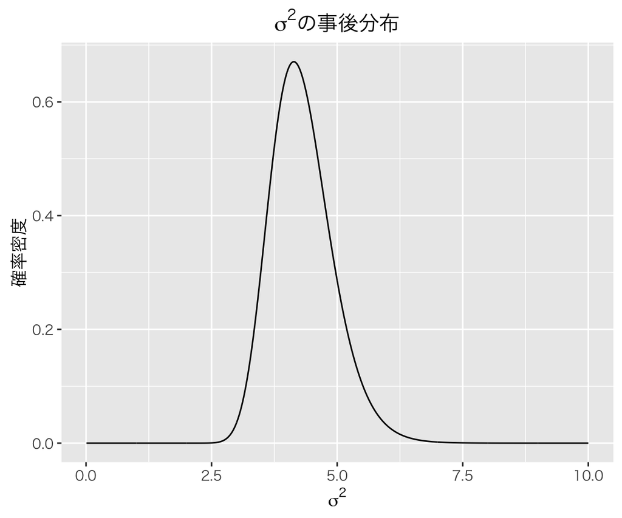

```r
# 分散の事後分布を得る
sigma <- seq(0.01, 10.0, by = 0.01)
post_sigma <- data.frame(sigma = sigma, pdf = dinvchisq(sigma, 99, var(y)))

# 図示
plot_sigma <- ggplot(post_sigma, aes(sigma, pdf)) +
  geom_line() +
  labs(x = expression(sigma^2), y = "確率密度",
       title = expression(paste(sigma^2, "の事後分布")))
print(plot_sigma)
```

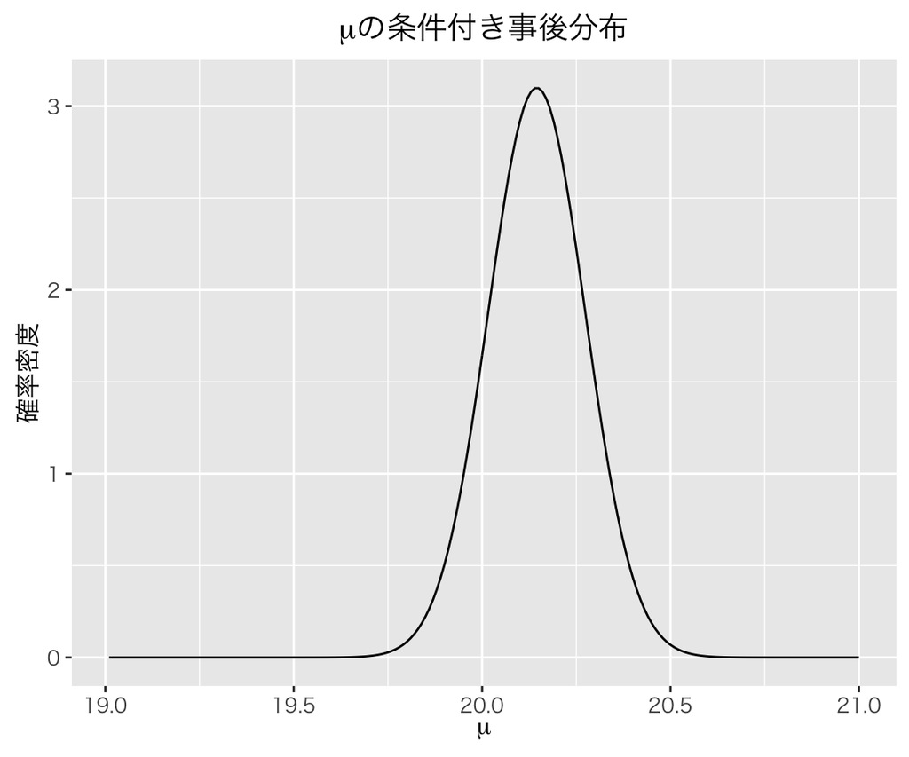

```r
# 平均の事後分布を得る
mu <- seq(19.01, 21.0, by = 0.01)
sigma <- post_sigma$sigma[post_sigma$pdf == max(post_sigma$pdf)] ## MAPの近似値
post_mu <- data.frame(mu = mu, pdf = dnorm(mu, mean(y), sqrt(sigma/250)))

# 図示
plot_mu <- ggplot(post_mu, aes(mu, pdf)) +
  geom_line() +
  labs(x = expression(mu), y = "確率密度",
       title = expression(paste(mu, "の条件付き事後分布")))
print(plot_mu)
```

$\mu$と$\sigma^2$の同時事後分布も描いてみる。無情報事前分布を想定し、$p(\mu,\sigma^2) \propto (\sigma^2)^-1$であるので、(3.2)の式である
$$p(\mu,\sigma^2|y) = \sigma^{-n-2} \mathrm{exp}\biggl(-\frac{(n-1)s^2 + n(\bar{y}-\mu)^2}{2\sigma^2}\biggr)$$
が同時事後分布となる。

まず、$\mu$と$\sigma^2$の格子を作る。

```r
mu <- seq(18, 21, by = 0.01)
sigma <- seq(2.5, 6.5, by = 0.01)
Grid <- expand.grid(mu, sigma)
names(Grid) <- c("mu", "sigma^2")
```

続いて、各格子点での事後確率を上の式から計算する。

```r
# 各格子点での事後確率を求める関数を自作
post_grid <- function(grid, y) {
  mu <- grid$mu
  sigma <- grid$sigma
  n <- length(y)
  post <- sqrt(sigma)^(-n-2) * exp(-((n-1)*var(y)+n*(mean(y)-mu)^2) / (2*sigma))
  return(post)
}

# 同時事後確率を計算
Grid$post <- post_grid(Grid, y)
```

同時事後分布をプロットしてみよう。

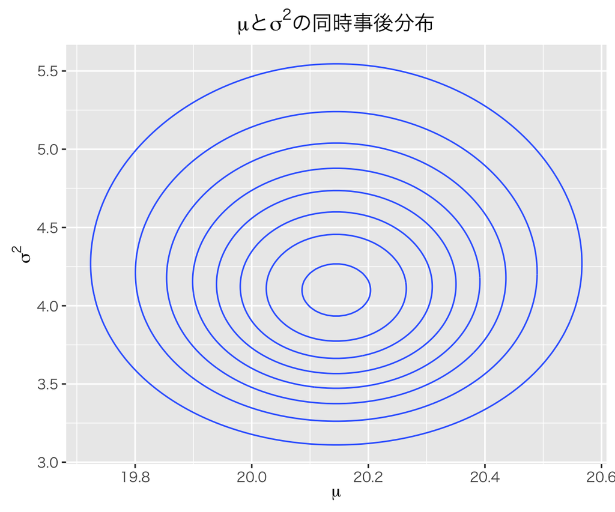

```r
plot_post <- ggplot(Grid, aes(x = mu, y = `sigma^2`, z = post)) +
  geom_contour() +
  labs(x = expression(mu), y = expression(sigma^2),
       title = expression(paste(mu, "と", sigma^2, "の同時事後分布")))
print(plot_post)
```

# カテゴリカルなデータに対する推定

生物検定実験の分析を再現しながら、理解度を確認しよう。まず、元となるデータはTable 3.1である。

```r
data <- data.frame(x = c(-0.86, -0.30, -0.05, 0.73),
                   n = rep(5, 4),
                   y = c(0, 1, 3, 5))
```

各動物は死ぬか生きるかの二択である。また、死ぬ確率は薬の投与量に影響される。このことを踏まえ、以下のモデルを考える。
$$y_i|\theta_i \sim \mathrm{Bin}(n_i, \theta_i)$$
$$\mathrm{logit}(\theta_i) = \alpha + \beta x_i$$
推定するパラメタは$\alpha$と$\beta$の2つである。

二項分布を想定していることから、このモデルの尤度は、
$$p(y_i | \alpha, \beta, x_i, n_i) = \theta^{y_i}_{i} \cdot (1 - \theta_i)^{n_i - y_i}$$
である。

事前分布は無情報とするため、$p(\alpha,\beta) \propto 1$と考える。

尤度と事前分布から、$\alpha$と$\beta$の同時事後分布は、
$$p(\alpha, \beta | y, n, x) \propto \prod_{i=1}^k p(y_i | \alpha, \beta, n_i, x_i)$$
となる。

では、同時事後分布の等高線を再現しよう。

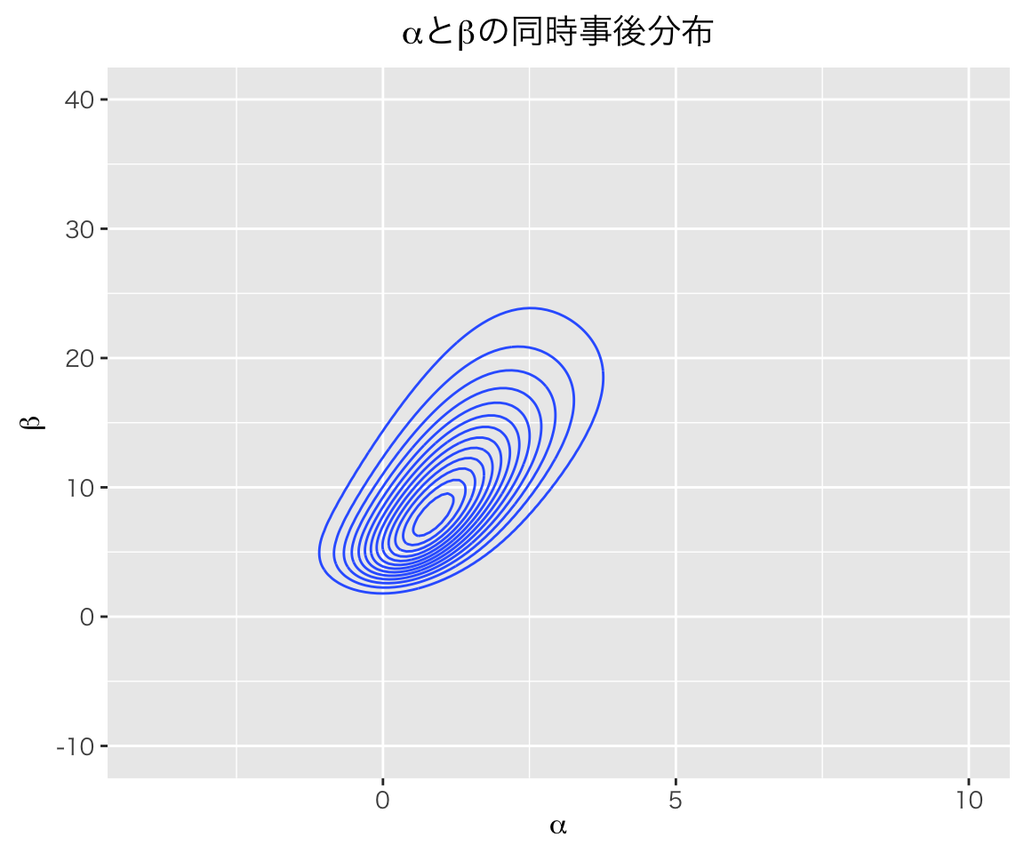

```r
# 格子の準備
a <- seq(-5, 10, by = 0.1)
b <- seq(-10, 40, by = 0.1)
Grid <- expand.grid(a, b)
names(Grid) <- c("alpha", "beta")

# ロジスティック関数を自作
invlogit <- function(x){
    y <- 1 / (1 + exp(-x))
    return(y)
}

# 各格子点での事後確率を求める関数を自作
post_grid <- function(grid, data) {
  a <- grid$alpha
  b <- grid$beta
  x <- data$x
  n <- 5
  y <- data$y
  m <- length(a)
  post <- rep(NA, m)
  for (i in 1:m) {
    lik <- (invlogit(a[i] + b[i] * x))^y *
              (1 - invlogit(a[i] + b[i] * x))^(n - y)
    post[i] <- prod(lik)
  }
  return(post)
}

# 同時事後確率を計算
Grid$post <- post_grid(Grid, data)

# 等高線をプロット
plot_post <- ggplot(Grid, aes(x = alpha, y = beta, z = post)) +
  geom_contour() +
  xlim(-4, 10) + ylim(-10, 40) +
  labs(x = expression(alpha), y = expression(beta),
       title = expression(paste(alpha, "と", beta, "の同時事後分布")))
print(plot_post)
```

Figure 3.3(a)が再現できた。

続いて、事後分布からサンプリングを行う。まずは$\alpha$の周辺事後分布を作ろう。

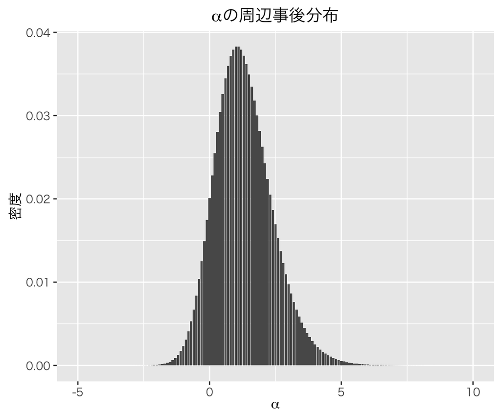

```r
mg_alpha <- ddply(Grid, .(alpha), summarize, density = sum(post)) ## 周辺化
mg_alpha$density <- with(mg_alpha, density / sum(density)) ## 正規化

# 試しにプロット
plot_mg_alpha <- ggplot(mg_alpha, aes(alpha, density)) +
  geom_bar(stat = "identity") +
  labs(x = expression(alpha), y = "密度",
       title = expression(paste(alpha, "の周辺事後分布")))
print(plot_mg_alpha)
```

次に、以下の作業を1000回繰り返す。

1. 周辺事後分布に従って$\alpha$をサンプリング。
2. サンプリングした$\alpha$と同時事後分布に従って、$\beta$をサンプリング。
3. 格子の間の値も考慮するために、サンプリング結果をランダムにずらす。

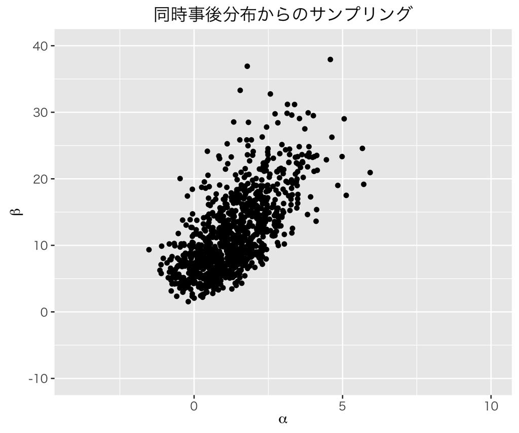

```r
# サンプリング結果の保存先
Sampling <- data.frame(alpha = rep(NA, 1000), beta = rep(NA, 1000))

# 作業を1000回繰り返す
for (i in 1:1000) {
  # αのサンプリング
  a <- sample(mg_alpha$alpha, size = 1, prob = mg_alpha$density)
  # βのサンプリング
  ## 抽出したαに対応するβとの同時事後確率を正規化
  p <- with(Grid[Grid$alpha == a,], post / sum(post))
  ## サンプリング
  b <- sample(Grid$beta[Grid$alpha == a], size = 1, prob = p)
  # ずらして保存
  Sampling$alpha[i] <- a + runif(1, min = -0.05, max = 0.05)
  Sampling$beta[i] <- b + runif(1, min = -0.05, max = 0.05)
}

# 作業結果を散布図で示す
plot_sampling <- ggplot(Sampling, aes(alpha, beta)) +
  geom_point() +
  xlim(-4, 10) + ylim(-10, 40) +
  labs(x = expression(alpha), y = expression(beta),
       title = "同時事後分布からのサンプリング")
print(plot_sampling)
```

Figure 3.3(b)を再現できた。